# Сравнение подходов к ранжированию

Тушавин В. А.

4 января 2016 г.

Целью настоящего исследования является сравнение алгоритмов ранжирования объектов с точки зрения их эффективности.

Сравниваются три алгоритма. Два из них были ранее описаны в статье Тушавин В. А. Ранжирование показателей качества с использованием методов Кемени-Янга и Шульце //Экономика и менеджмент систем управления. 2005. № 4.4.

Третий - быстрый алгоритм нахождения медианы Кемени из пакета `ConsRank`.

### Определение библиотек и функций

```r
library(ggplot2)
library(scales)
library(gtools)
library(ConsRank)
library(lpSolve)
library(irr)
library(reshape2)
library(VennDiagram)
library(rpart)
library(rpart.plot)
library(caret)
library(ROCR)
# Функции для нахождения медианы Кемени
# Нахождение расстояния между оценками
kendall_tau<-function(rank.a,rank.b) {
  tau<-0
  n<-length(rank.a)
  for(k in 1:ncol(z<-combn(n,2))) {
    i=z[1,k]
    j=z[2,k]
    tau<-tau+(sign(rank.a[i]-rank.a[j]) == -sign(rank.b[i]-rank.b[j]))
  }
  return(tau)
}


# Построение графа
build_graph<-function(ranks) {
  n_voters<-nrow(ranks)
  n_candidates<-ncol(ranks)
  edge_weights<-matrix(0,nrow=n_candidates,ncol=n_candidates)
  for(k in 1:ncol(z<-combn(n_candidates,2))) {
    i=z[1,k]
    j=z[2,k]
    preference<-ranks[, i] - ranks[, j]
    h.ij <- sum(preference < 0)
    h.ji <- sum(preference > 0)
    if(h.ij > h.ji) edge_weights[i, j] <- h.ij - h.ji else if(h.ij < h.ji) edge_weights[j, i] <- h.ji - h.ij
  }
  return(edge_weights)
}

# Нахождение медианы Кемени посредством решения задачи ЛП
rank_solve<-function(ranks,Wk=NULL) {
  tic = proc.time()[3]
  n_voters<-nrow(ranks)
  n_candidates<-ncol(ranks)
  # Строим граф
  edge_weights<-build_graph(ranks)
  # Задаем параметры.
  # Коээфициенты при целевой функции
  objective.in<- as.vector(t(edge_weights))
  # Коэффициенты для каждой пары
  pairwise_constraints <- matrix(0,
                                 n_candidates * (n_candidates - 1) / 2, n_candidates ^ 2)
  for(k in 1:nrow(z<-combinations(n_candidates,2))) {
    i=z[k,1]
    j=z[k,2]
    pairwise_constraints[k,c((i-1)*n_candidates+j,(j-1)*n_candidates+i)]<-1
  }
  # Коэффициенты для каждой тройки
  triangle_constraints <-matrix(0,n_candidates *
                                  (n_candidates - 1) *
                                  (n_candidates - 2), n_candidates ^ 2)

  for(m in 1:nrow(z<-permutations(n_candidates,3))) {
    i=z[m,1]
    j=z[m,2]
    k=z[m,3]
    triangle_constraints[m,c((i-1)*n_candidates+j,(j-1)*n_candidates+k,(k-1)*n_candidates+i)]<-1
  }
  constraints<-rbind(pairwise_constraints,triangle_constraints)
  constraint_rhs<-rep(1,nrow(pairwise_constraints)+nrow(triangle_constraints))
  constraint_signs<-c(rep("==",nrow(pairwise_constraints)),rep(">=",nrow(triangle_constraints)))
  z<-lp("min",objective.in, constraints, constraint_signs, constraint_rhs,all.int=T)
  x<-matrix(z$solution,nrow=n_candidates,ncol=n_candidates,byrow=T)
  best_rank<-apply(x,1,sum)
  tau<-sum(apply(ranks,1,function(x){kendall_tau(x,best_rank)}))
  toc = proc.time()[3]
  eltime = toc - tic
  consensus<-matrix(best_rank+1,nrow=1,ncol=n_candidates)
  colnames(consensus)<-colnames(ranks)
  return(list(min_dist=tau,best_rank=best_rank,Consensus=consensus,Eltime=eltime))
}
```

Поскольку предыдущая версия функции ранжирования методом Шульце требовала полное ранжирование заданное в виде последовательности номеров элементов, то необходимо её немного преобразовать для работы с таблицей рангов.

```r
# Модифицированния функция нахождения итогового
# ранжирования методом Шульце
Schulze.m<-function(ranks,Wk=NULL) {
  tic = proc.time()[3]
  if (class(ranks) == "data.frame") {
    ranks = as.matrix(ranks)
  }
  n_voters<-nrow(ranks)
  n_candidates<-ncol(ranks)
  ranks[is.na(ranks)]<-Inf
  if (n_voters == 1) {
    consensus = ranks
  } else {
    mtx<-matrix(data=0,nrow=n_candidates,ncol=n_candidates)
    rownames(mtx)<-colnames(ranks)
    colnames(mtx)<-colnames(ranks)
    index<-combinations(n_candidates,2)
    for(i in 1:n_voters){
      temp<-matrix(data=0,nrow=n_candidates,ncol=n_candidates)
      for(idx in 1:nrow(index)) {
        x1=index[idx,1]
        x2=index[idx,2]
        if(ranks[i,x1]<ranks[i,x2]) temp[x1,x2]<-temp[x1,x2]+1
        if(ranks[i,x1]>ranks[i,x2]) temp[x2,x1]<-temp[x2,x1]+1
      }
      if(!is.null(Wk)) temp<-temp*Wk[i]
      mtx<-mtx+temp
    }
  result<-matrix(data=0,nrow=n_candidates,ncol=n_candidates)
  for(i in 1:n_candidates)
    for(j in 1:n_candidates)
      if(i!=j) result[i,j]<-ifelse(mtx[i,j] > mtx[j,i],mtx[i,j],0)
  for(i in 1:n_candidates)
    for(j in 1:n_candidates)
      if(i!=j) for(k in 1:n_candidates)
        if(i!=k & j !=k) result[j,k]<-max(result[j,k],
                                        min(result[j,i],result[i,k]))
  vec<-rep(0,n_candidates)
  for(k in 1:nrow(z<-combinations(n_candidates,2))) {
    i=z[k,1]
    j=z[k,2]
    if(result[i,j]>result[j,i])
      vec[j]<-vec[j]+1
    else if(result[i,j]<result[j,i])
      vec[i]<-vec[i]+1
  }
  }
  consensus<-matrix(vec,nrow=1,ncol=n_candidates)
  colnames(consensus)<-colnames(ranks)
toc = proc.time()[3]
eltime = toc - tic
return(list(Consensus=consensus+1,Schulze=result,Eltime=eltime))
}

Rcpp::sourceCpp('schulze.cpp')
```

Проведем тестирование на [примере из Википедии](https://en.wikipedia.org/wiki/Schulze_method)

| number of voters | order of preference |
| --- | --- |
| 5 | ACBED |
| 5 | ADECB |
| 8 | BEDAC |
| 3 | CABED |
| 7 | CAEBD |
| 2 | CBADE |
| 7 | DCEBA |
| 8 | EBADC |

Schulze ranking is E > A > C > B > D, and E wins.

```r
test<-data.frame(order=c("ACBED","ADECB",
                 "BEDAC",
                 "CABED",
                 "CAEBD",
                 "CBADE",
                 "DCEBA",
                 "EBADC"),
                  wk=c(5,5,8,3,7,2,7,8))
ranks<-matrix(0,nrow=nrow(test),ncol=5)
colnames(ranks)<-LETTERS[1:5]
for(i in 1:nrow(test))
  ranks[i,t(asc(as.character(test$order[i]))-64)]<-1:5
Wk<-test$wk
Schulze.m(ranks,Wk)
```

```
## $Consensus
##      A B C D E
## [1,] 2 4 3 5 1
##
## $Schulze
##      [,1] [,2] [,3] [,4] [,5]
## [1,]    0   28   28   30   24
## [2,]   25    0   28   33   24
## [3,]   25   29    0   29   24
## [4,]   25   28   28    0   24
## [5,]   25   28   28   31    0
##
## $Eltime
## elapsed
##    0.02
```

Результаты совпали полностью. Функция работает. Проверим результат с помощью пакета `ConsRank`

```r
FASTcons(ranks,Wk)
```

```
## $Consensus
##      A B C D E
## [1,] 3 2 5 4 1
##
## $Tau
##           [,1]
## [1,] 0.1555556
##
## $Eltime
## elapsed
##   3.397
```

```r
QuickCons(ranks,Wk)
```

```
## $Consensus
##      A B C D E
## [1,] 3 2 5 4 1
##
## $Tau
## [1] 0.1555556
##
## $Eltime
## elapsed
##   0.141
```

```r
EMCons(ranks,Wk)
```

```
## [1] "round 1"
## [1] "evaluating 1 branches"
## [1] "evaluating 3 branches"
## [1] "evaluating 13 branches"
## [1] "evaluating 33 branches"
## [1] "round 2"
## [1] "evaluating 1 branches"
## [1] "evaluating 3 branches"
## [1] "evaluating 13 branches"
## [1] "evaluating 18 branches"
```

```
## $Consensus
##      A B C D E
## [1,] 3 2 5 4 1
##
## $Tau
## [1] 0.1555556
##
## $Eltime
## elapsed
##   0.336
```

Имеется расхождение, поскольку пример является несбалансированным по рангам.

Сравним результаты тестового примера из пакета `ConsRank`. Данные представляют собой ранжирование 130 студентами семи видов спорта в соответствии с их предпочтениями. (Marden, J. I. (1996). Analyzing and modeling rank data. CRC Press.)

```r
data(sports)
colnames(sports)
```

```
## [1] "Baseball"   "Football"   "Basketball" "Tennis"     "Cycling"
## [6] "Swimming"   "Jogging"
```

```r
colnames(sports)<-c("Бейсбол", "Футбол", "Баскетбол", "Теннис", "Велоспорт", "Плавание", "Бег трусцой")
dim(sports)
```

```
## [1] 130   7
```

```r
FASTcons(sports,maxiter=10)
```

```
## $Consensus
##      Бейсбол Футбол Баскетбол Теннис Велоспорт Плавание Бег трусцой
## [1,]       4      6         3      5         1        2           7
##
## $Tau
##           [,1]
## [1,] 0.1443223
##
## $Eltime
## elapsed
##   1.087
```

```r
QuickCons(sports)
```

```
## $Consensus
##      Бейсбол Футбол Баскетбол Теннис Велоспорт Плавание Бег трусцой
## [1,]       4      6         3      5         1        2           7
##
## $Tau
##           [,1]
## [1,] 0.1443223
##
## $Eltime
## elapsed
##   0.298
```

```r
EMCons(sports)
```

```
## [1] "round 1"
## [1] "evaluating 1 branches"
## [1] "evaluating 1 branches"
## [1] "evaluating 1 branches"
## [1] "evaluating 1 branches"
## [1] "evaluating 1 branches"
## [1] "evaluating 1 branches"
```

```
## $Consensus
##      Бейсбол Футбол Баскетбол Теннис Велоспорт Плавание Бег трусцой
## [1,]       4      6         3      5         1        2           7
##
## $Tau
## [1] 0.1443223
##
## $Eltime
## elapsed
##   0.237
```

```r
# Версия на R
Schulze.m(sports)
```

```
## $Consensus
##      Бейсбол Футбол Баскетбол Теннис Велоспорт Плавание Бег трусцой
## [1,]       4      6         3      5         1        2           7
##
## $Schulze
##      [,1] [,2] [,3] [,4] [,5] [,6] [,7]
## [1,]    0   81    0   66    0    0   82
## [2,]    0    0    0    0    0    0   72
## [3,]   69   76    0   66    0    0   88
## [4,]    0   70    0    0    0    0   89
## [5,]   69   73   69   71    0   71   96
## [6,]   66   70   66   72    0    0   86
## [7,]    0    0    0    0    0    0    0
##
## $Eltime
## elapsed
##   0.096
```

```r
#Версия на C++
Schulze_M(sports)
```

```
## $Consensus
##      Бейсбол Футбол Баскетбол Теннис Велоспорт Плавание Бег трусцой
## [1,]       4      6         3      5         1        2           7
##
## $Schulze
##      [,1] [,2] [,3] [,4] [,5] [,6] [,7]
## [1,]    0   81    0   66    0    0   82
## [2,]    0    0    0    0    0    0   72
## [3,]   69   76    0   66    0    0   88
## [4,]    0   70    0    0    0    0   89
## [5,]   69   73   69   71    0   71   96
## [6,]   66   70   66   72    0    0   86
## [7,]    0    0    0    0    0    0    0
##
## $Eltime
##    elapsed
## 0.00011846
```

```r
rank_solve(sports)
```

```
## $min_dist
## [1] 1168
##
## $best_rank
## [1] 3 5 2 4 0 1 6
##
## $Consensus
##      Бейсбол Футбол Баскетбол Теннис Велоспорт Плавание Бег трусцой
## [1,]       4      6         3      5         1        2           7
##
## $Eltime
## elapsed
##   0.138
```

Результаты совпадают.

### Сравнение времени выполнения алгоритмов

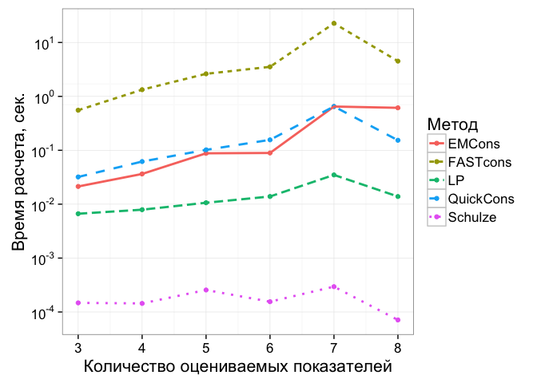

```r
#  Тест по времени
set.seed(1968)
d.len<-c()
d.n<-c()
d.mth<-c()
d.time<-c()

pb <- txtProgressBar(min = 0, max = 24, style = 3,file = stderr())
zzz<-0
for(rank_len in 3:8)
  for(n_ranks in c(5,10,15,20)) {
    ranks<-c()
    for(i in 1:n_ranks) ranks<-c(ranks,sample(1:rank_len,rank_len))
    ranks<-matrix(ranks,ncol=rank_len,byrow=T)

    start.time <- Sys.time()
    z<-FASTcons(ranks)
    end.time <- Sys.time()
    time.taken <-end.time - start.time
    d.len<-c(d.len,rank_len)
    d.n<-c(d.n,n_ranks)
    d.mth<-c(d.mth,"FASTcons")
    d.time<-c(d.time,as.numeric(time.taken))

     start.time <- Sys.time()
    z<-QuickCons(ranks)
    end.time <- Sys.time()
    time.taken <- end.time - start.time
    d.len<-c(d.len,rank_len)
    d.n<-c(d.n,n_ranks)
    d.mth<-c(d.mth,"QuickCons")
    d.time<-c(d.time,as.numeric(time.taken))

    start.time <- Sys.time()
    z<-EMCons(ranks,PS=F)
    end.time <- Sys.time()
    time.taken <- end.time - start.time
    d.len<-c(d.len,rank_len)
    d.n<-c(d.n,n_ranks)
    d.mth<-c(d.mth,"EMCons")
    d.time<-c(d.time,as.numeric(time.taken))

    start.time <- Sys.time()
    z<-Schulze_M(ranks)
    end.time <- Sys.time()
    time.taken <- end.time - start.time
    d.len<-c(d.len,rank_len)
    d.n<-c(d.n,n_ranks)
    d.mth<-c(d.mth,"Schulze")
    d.time<-c(d.time,as.numeric(time.taken))

    start.time <- Sys.time()
    z<-rank_solve(ranks)
    end.time <- Sys.time()
    time.taken <- end.time - start.time
    d.len<-c(d.len,rank_len)
    d.n<-c(d.n,n_ranks)
    d.mth<-c(d.mth,"LP")
    d.time<-c(d.time,as.numeric(time.taken))
    zzz<-zzz+1
    setTxtProgressBar(pb, zzz)
  }
close(pb)

mydata<-data.frame(Показателей=d.len,Экспертов=d.n,Время=d.time,Метод=d.mth)
mydata$Экспертов<-as.factor(mydata$Экспертов)
mydata$Метод<-as.factor(mydata$Метод)
g<-ggplot(aggregate(Время~Показателей+Метод,data=mydata,mean),aes(x=Показателей,y=Время,linetype=Метод,col=Метод))+
  geom_point()+
  geom_line(size=1)+
  scale_y_log10(breaks=trans_breaks("log10",function(x) 10^x),
                labels=trans_format("log10",math_format(10^.x)),
                minor_breaks=log10(5)+-4:1)+
  xlab("Количество оцениваемых показателей")+ylab("Время расчета, сек.")
g<-g+theme_bw(base_size = 16)
g  #+theme(legend.position=c(1,1),legend.justification=c(1,1))
```

### Задание функций тестирования

Пусть имеется матрица рангов n x m, где n - эксперты, а m - ранжируемые показатели и имеется случайный вектор рангов длиной m. Пусть имеется полный конценсус и все эксперты поставили одинаковую оценку равную этому случайному вектору. Внесем искажения в матрицу, поменяв в каждой строке, кроме первой, два случайно выбранных рядом стоящих ранга местами. Попробуем отыскать исходное ранжирование с помощью метода Шульце, медианы Кемени методом ЛП и методом ветвей и границ.

```r
change<-function(vec,cnt=1) {
  idx<-1:(length(vec)-1)
  for(i in 1:cnt) {
    k<-sample(idx,1)
    x1<-which(vec==k)
    x2<-which(vec==(k+1))
    x<-vec[x1]
    vec[x1]<-vec[x2]
    vec[x2]<-x
  }
  return(vec)
}

dotest<-function(val=5,experts=10,tests=1,correct=0) {
  result<-list()
  # Start
  for(i in 1:tests) {
    x0<-sample(1:val,val)
    names(x0)<-LETTERS[1:val]
    z<-matrix(rep(x0,experts),byrow=T,ncol=val)
    colnames(z)<-LETTERS[1:val]
    z1<-t(apply(z,1,change,cnt=1))
    if(correct>0) for(j in 1:correct) z1[j,]<-x0
    result[[i]]<-list(kendall=kendall(t(z1)),
                      TrueValue=x0,
                      Shulze=Schulze_M(z1),
                      FASTcons=QuickCons(z1),
                      LP=rank_solve(z1-1))
  }
return(result)
}
```

### Тестирование

```r
if(!file.exists("doe.RDs")) {
  set.seed(2015)
  doe<-expand.grid(testn=1:100,val=3:8,experts=c(4,8,16,32,64,128,256,512))
  doe$W<-NA
  doe$Shulze.time<-NA
  doe$FASTcons.time<-NA
  doe$LP.time<-NA
  doe$TS<-""
  doe$Sch<-""
  doe$Ken<-""
  doe$LP<-""
  doe$TrueS<-FALSE
  doe$TrueF<-FALSE
  doe$TrueLP<-FALSE
  doe$SF<-FALSE
  doe$SLP<-FALSE
  doe$FLP<-FALSE

  pb <- txtProgressBar(min = 0, max = nrow(doe), style = 3,file = stderr())
  for(i in 1:nrow(doe)) {
    r1<-dotest(val=doe$val[i],experts=doe$experts[i],tests=1,correct=1)
    doe$W[i]<-r1[[1]]$kendall$value
    doe$Shulze.time[i]<-r1[[1]]$Shulze$Eltime
    doe$FASTcons.time[i]<-r1[[1]]$FASTcons$Eltime
    doe$LP.time[i]<-r1[[1]]$LP$Eltime

    doe$TS[i]<-paste0(names(r1[[1]]$TrueValue)[order(r1[[1]]$TrueValue)],collapse="")
    doe$Sch[i]<-paste0(names(r1[[1]]$Shulze$Consensus[1,])[order(r1[[1]]$Shulze$Consensus[1,])],collapse="")
    doe$Ken[i]<-paste0(names(r1[[1]]$FASTcons$Consensus[1,])[order(r1[[1]]$FASTcons$Consensus[1,])],collapse="")
    doe$LP[i]<-paste0(names(r1[[1]]$LP$Consensus[1,])[order(r1[[1]]$LP$Consensus[1,])],collapse="")

    doe$TrueS[i]<-(doe$TS[i] == doe$Sch[i])
    doe$TrueF[i]<-(doe$TS[i] == doe$Ken[i])
    doe$TrueLP[i]<-(doe$TS[i] == doe$LP[i])
    doe$SF[i]<-(doe$Sch[i] == doe$Ken[i])
    doe$SLP[i]<-(doe$Sch[i] == doe$LP[i])
    doe$FLP[i]<-(doe$Ken[i] == doe$LP[i])
    setTxtProgressBar(pb, i)
  }
  close(pb)
  ### Сохранение данных
  saveRDS(doe,"doe.RDs")
  library(xlsx)
  write.xlsx(doe, "mydata.xlsx", sheetName="Results",row.names=FALSE)
} else doe<-readRDS("doe.RDs")

knitr::kable(agg.doe<-aggregate(cbind(TrueS,TrueF,TrueLP,SF,SLP,FLP,Shulze.time,FASTcons.time,LP.time)~val+experts,data=doe,sum))
```

| val | experts | TrueS | TrueF | TrueLP | SF | SLP | FLP | Shulze.time | FASTcons.time | LP.time |
| --- | --- | --- | --- | --- | --- | --- | --- | --- | --- | --- |
| 3 | 4 | 37 | 36 | 0 | 67 | 63 | 64 | 0.0006134 | 0.984 | 0.207 |
| 4 | 4 | 52 | 60 | 37 | 80 | 53 | 45 | 0.0005918 | 1.159 | 0.232 |
| 5 | 4 | 67 | 64 | 52 | 87 | 57 | 64 | 0.0006976 | 1.959 | 0.370 |
| 6 | 4 | 72 | 73 | 63 | 93 | 67 | 68 | 0.0009001 | 2.760 | 0.481 |
| 7 | 4 | 76 | 77 | 68 | 95 | 62 | 65 | 0.0009591 | 3.968 | 0.726 |
| 8 | 4 | 89 | 86 | 79 | 95 | 72 | 75 | 0.0011465 | 5.687 | 1.137 |
| 3 | 8 | 26 | 25 | 0 | 69 | 74 | 75 | 0.0005847 | 1.133 | 0.261 |
| 4 | 8 | 58 | 61 | 40 | 85 | 80 | 77 | 0.0007142 | 1.854 | 0.558 |
| 5 | 8 | 85 | 85 | 79 | 92 | 86 | 86 | 0.0009325 | 2.349 | 0.473 |
| 6 | 8 | 93 | 91 | 87 | 98 | 94 | 96 | 0.0008912 | 2.700 | 0.522 |
| 7 | 8 | 93 | 93 | 92 | 98 | 97 | 97 | 0.0010195 | 4.058 | 0.812 |
| 8 | 8 | 98 | 97 | 95 | 99 | 97 | 98 | 0.0012233 | 6.320 | 1.299 |
| 3 | 16 | 15 | 12 | 0 | 83 | 85 | 88 | 0.0005927 | 1.354 | 0.333 |
| 4 | 16 | 81 | 80 | 74 | 95 | 93 | 94 | 0.0007365 | 2.010 | 0.425 |
| 5 | 16 | 99 | 99 | 98 | 100 | 99 | 99 | 0.0008739 | 3.078 | 0.648 |
| 6 | 16 | 99 | 100 | 99 | 99 | 100 | 99 | 0.0011506 | 3.172 | 0.762 |
| 7 | 16 | 100 | 100 | 99 | 100 | 99 | 99 | 0.0012624 | 4.840 | 1.268 |
| 8 | 16 | 99 | 100 | 99 | 99 | 100 | 99 | 0.0014079 | 6.671 | 1.535 |
| 3 | 32 | 10 | 15 | 0 | 79 | 90 | 85 | 0.0006798 | 2.035 | 0.513 |
| 4 | 32 | 92 | 94 | 91 | 98 | 99 | 97 | 0.0008034 | 2.097 | 0.568 |
| 5 | 32 | 100 | 100 | 100 | 100 | 100 | 100 | 0.0012943 | 3.339 | 0.855 |
| 6 | 32 | 100 | 100 | 100 | 100 | 100 | 100 | 0.0011967 | 3.884 | 1.010 |
| 7 | 32 | 100 | 100 | 100 | 100 | 100 | 100 | 0.0015900 | 5.224 | 1.431 |
| 8 | 32 | 100 | 100 | 100 | 100 | 100 | 100 | 0.0017272 | 6.934 | 1.881 |
| 3 | 64 | 8 | 15 | 0 | 89 | 92 | 85 | 0.0007975 | 2.426 | 0.725 |
| 4 | 64 | 99 | 99 | 99 | 100 | 100 | 100 | 0.0010219 | 3.066 | 0.943 |
| 5 | 64 | 100 | 100 | 100 | 100 | 100 | 100 | 0.0013611 | 5.609 | 1.617 |
| 6 | 64 | 100 | 100 | 100 | 100 | 100 | 100 | 0.0018985 | 8.473 | 2.733 |
| 7 | 64 | 100 | 100 | 100 | 100 | 100 | 100 | 0.0023558 | 10.962 | 3.334 |
| 8 | 64 | 100 | 100 | 100 | 100 | 100 | 100 | 0.0025999 | 11.133 | 3.507 |
| 3 | 128 | 7 | 11 | 0 | 92 | 93 | 89 | 0.0009624 | 3.764 | 1.266 |
| 4 | 128 | 100 | 100 | 100 | 100 | 100 | 100 | 0.0013170 | 4.823 | 1.637 |
| 5 | 128 | 100 | 100 | 100 | 100 | 100 | 100 | 0.0017028 | 6.015 | 2.128 |
| 6 | 128 | 100 | 100 | 100 | 100 | 100 | 100 | 0.0020554 | 7.546 | 2.736 |
| 7 | 128 | 100 | 100 | 100 | 100 | 100 | 100 | 0.0030943 | 11.162 | 4.534 |
| 8 | 128 | 100 | 100 | 100 | 100 | 100 | 100 | 0.0035546 | 15.536 | 5.897 |
| 3 | 256 | 4 | 3 | 0 | 95 | 96 | 97 | 0.0013534 | 7.012 | 2.343 |
| 4 | 256 | 100 | 100 | 100 | 100 | 100 | 100 | 0.0020334 | 9.993 | 3.506 |
| 5 | 256 | 100 | 100 | 100 | 100 | 100 | 100 | 0.0026432 | 11.775 | 4.398 |
| 6 | 256 | 100 | 100 | 100 | 100 | 100 | 100 | 0.0034648 | 13.800 | 5.540 |
| 7 | 256 | 100 | 100 | 100 | 100 | 100 | 100 | 0.0042200 | 16.157 | 6.966 |
| 8 | 256 | 100 | 100 | 100 | 100 | 100 | 100 | 0.0051927 | 19.826 | 8.700 |
| 3 | 512 | 1 | 2 | 0 | 99 | 99 | 98 | 0.0022246 | 16.445 | 5.686 |
| 4 | 512 | 100 | 100 | 100 | 100 | 100 | 100 | 0.0031334 | 15.743 | 6.303 |
| 5 | 512 | 100 | 100 | 100 | 100 | 100 | 100 | 0.0042382 | 19.571 | 7.748 |
| 6 | 512 | 100 | 100 | 100 | 100 | 100 | 100 | 0.0056990 | 23.939 | 10.399 |
| 7 | 512 | 100 | 100 | 100 | 100 | 100 | 100 | 0.0073756 | 29.067 | 12.916 |
| 8 | 512 | 100 | 100 | 100 | 100 | 100 | 100 | 0.0092957 | 35.709 | 16.560 |

### Время выполнения скрипта в зависимости от алгоритма

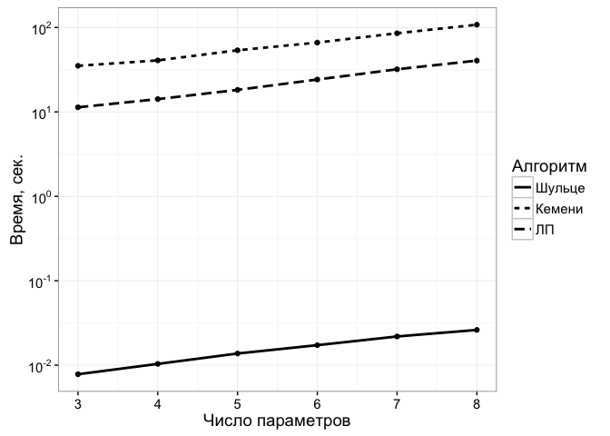

```r
agg.doe<-agg.doe[,c(1,2,9:11)]
names(agg.doe)[3:5]<-c("Шульце","Кемени","ЛП")
md<-melt(agg.doe,id=c("val","experts"))
md<-aggregate(value~val+variable,sum,data=md)
ggplot(md,aes(x=val,y=value,linetype=variable))+
  geom_line(size=1)+geom_point()+
 scale_linetype_discrete(name="Алгоритм")+
  scale_y_log10(breaks=trans_breaks("log10",function(x) 10^x),
                labels=trans_format("log10",math_format(10^.x)),
                minor_breaks=waiver())+
  labs(x="Число параметров",y="Время, сек.")+
  theme_bw()+theme(text=element_text(size=14))
```

```r
ggsave("Pictures/Artcl03/Pic03_00.png",width=6,height=4,dpi=300)
```

### Построение диаграммы Венна

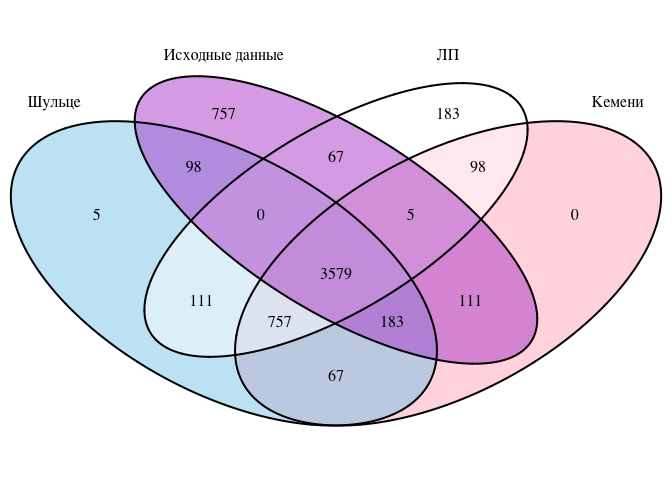

[output not shown]

```r
plot.venn<-function(doe) {
  grid.newpage()
  draw.quad.venn(area1 = nrow(doe),
                 area2 = nrow(doe),
                 area3 = nrow(doe),
                 area4=nrow(doe),
                 n12 = sum(doe$SF),
                 n13 = sum(doe$TrueS),
                 n14 = sum(doe$SLP),
                 n23 = sum(doe$TrueF),
                 n24 = sum(doe$FLP),
                 n34 = sum(doe$TrueLP),
                 n123 = sum(doe$Sch == doe$Ken & doe$Ken==doe$TS),
                 n124 = sum(doe$Sch == doe$Ken & doe$Ken==doe$LP),
                 n134 = sum(doe$Sch == doe$TS & doe$TS==doe$LP),
                 n234 = sum(doe$Ken == doe$TS & doe$TS==doe$LP),
                 n1234 = sum(doe$Ken == doe$TS & doe$TS==doe$LP & doe$Ken==doe$Sch),
                 category = c("Шульце", "Кемени", "Исходные данные", "ЛП"),
                 fill = c("skyblue", "pink1", "mediumorchid","white"))
}
plot.venn(doe)
```

# Анализ зависимости

```r
set.seed(2015)
idx<-sample(1:nrow(doe),3800)
test<-doe[idx,]
verify<-doe[-idx,]

(mylogit <- glm(TrueS ~ val + experts + W, data = test, family=binomial(link='logit')))
```

```
##
## Call:  glm(formula = TrueS ~ val + experts + W, family = binomial(link = "logit"),
##     data = test)
##
## Coefficients:
## (Intercept)          val      experts            W
##   -5.077245     0.707930     0.003041     4.254768
##
## Degrees of Freedom: 3799 Total (i.e. Null);  3796 Residual
## Null Deviance:       3710
## Residual Deviance: 2097  AIC: 2105
```

```r
summary(mylogit)
```

```
##
## Call:
## glm(formula = TrueS ~ val + experts + W, family = binomial(link = "logit"),
##     data = test)
##
## Deviance Residuals:
##      Min        1Q    Median        3Q       Max
## -3.10587   0.09522   0.19664   0.46476   1.94230
##
## Coefficients:
##               Estimate Std. Error z value Pr(>|z|)
## (Intercept) -5.0772454  0.2269911 -22.368  < 2e-16 ***
## val          0.7079303  0.0910490   7.775 7.53e-15 ***
## experts      0.0030411  0.0004047   7.515 5.71e-14 ***
## W            4.2547684  0.4587072   9.276  < 2e-16 ***
## ---
## Signif. codes:  0 '***' 0.001 '**' 0.01 '*' 0.05 '.' 0.1 ' ' 1
##
## (Dispersion parameter for binomial family taken to be 1)
##
##     Null deviance: 3709.8  on 3799  degrees of freedom
## Residual deviance: 2097.3  on 3796  degrees of freedom
## AIC: 2105.3
##
## Number of Fisher Scoring iterations: 6
```

```r
confint(mylogit)
```

```
##                    2.5 %       97.5 %
## (Intercept) -5.532272880 -4.641835510
## val          0.533344617  0.890616275
## experts      0.002261516  0.003848818
## W            3.360742352  5.160190314
```

```r
fitted.results<-predict(mylogit,newdata=verify,type='response')
fitted.results <- (fitted.results > 0.5)
confusionMatrix(fitted.results,verify$TrueS)
```

```
## Confusion Matrix and Statistics
##
##           Reference
## Prediction FALSE TRUE
##      FALSE   158   21
##      TRUE     55  766
##
##                Accuracy : 0.924
##                  95% CI : (0.9058, 0.9397)
##     No Information Rate : 0.787
##     P-Value [Acc > NIR] : < 2.2e-16
##
##                   Kappa : 0.7593
##  Mcnemar's Test P-Value : 0.0001535
##
##             Sensitivity : 0.7418
##             Specificity : 0.9733
##          Pos Pred Value : 0.8827
##          Neg Pred Value : 0.9330
##              Prevalence : 0.2130
##          Detection Rate : 0.1580
##    Detection Prevalence : 0.1790
##       Balanced Accuracy : 0.8576
##
##        'Positive' Class : FALSE
##
```

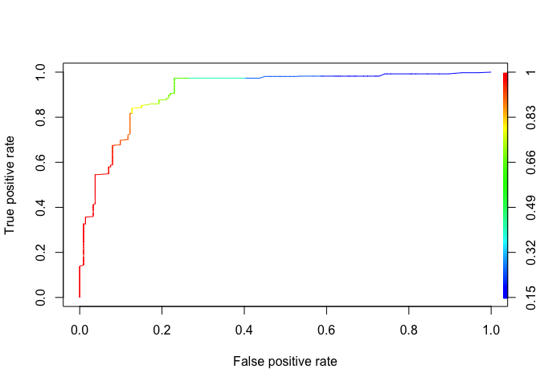

```r
fitted.results<-predict(mylogit,newdata=verify,type='response')
pr <- prediction(fitted.results, verify$TrueS)
prf <- performance(pr, measure = "tpr", x.measure = "fpr")
plot(prf,colorize=T)
```

```r
auc <- performance(pr, measure = "auc")
auc <- auc@y.values[[1]]
auc
```

```
## [1] 0.9147771
```

```r
(mytree <- rpart(as.factor(TrueS) ~ val + experts + W, data = test))
```

```
## n= 3800
##
## node), split, n, loss, yval, (yprob)
##       * denotes terminal node
##
##  1) root 3800 727 TRUE (0.19131579 0.80868421)
##    2) val< 3.5 615  87 FALSE (0.85853659 0.14146341) *
##    3) val>=3.5 3185 199 TRUE (0.06248038 0.93751962)
##      6) experts< 12 813 173 TRUE (0.21279213 0.78720787)
##       12) val< 4.5 162  71 TRUE (0.43827160 0.56172840)
##         24) W>=0.7375 84  27 FALSE (0.67857143 0.32142857) *
##         25) W< 0.7375 78  14 TRUE (0.17948718 0.82051282) *
##       13) val>=4.5 651 102 TRUE (0.15668203 0.84331797) *
##      7) experts>=12 2372  26 TRUE (0.01096121 0.98903879) *
```

```r
prp(mytree,type = 2,extra = 104,fallen.leaves=TRUE)
```

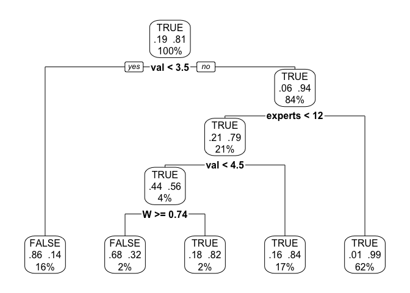

```r
fitted.results<-predict(mytree,newdata=verify,type = "class")
misClasificError <- mean(fitted.results != verify$TrueS)
print(paste('Accuracy',1-misClasificError))
```

```
## [1] "Accuracy 0.936"
```

```r
confusionMatrix(fitted.results,verify$TrueS)
```

```
## Confusion Matrix and Statistics
##
##           Reference
## Prediction FALSE TRUE
##      FALSE   178   29
##      TRUE     35  758
##
##                Accuracy : 0.936
##                  95% CI : (0.919, 0.9504)
##     No Information Rate : 0.787
##     P-Value [Acc > NIR] : <2e-16
##
##                   Kappa : 0.8071
##  Mcnemar's Test P-Value : 0.532
##
##             Sensitivity : 0.8357
##             Specificity : 0.9632
##          Pos Pred Value : 0.8599
##          Neg Pred Value : 0.9559
##              Prevalence : 0.2130
##          Detection Rate : 0.1780
##    Detection Prevalence : 0.2070
##       Balanced Accuracy : 0.8994
##
##        'Positive' Class : FALSE
##
```

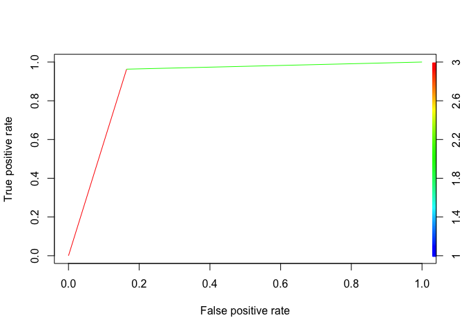

```r
pr <- prediction(predict(mytree,newdata=verify,type = "vector"), verify$TrueS)
prf <- performance(pr, measure = "tpr", x.measure = "fpr")
plot(prf,colorize=T)
```

```r
auc <- performance(pr, measure = "auc")
auc <- auc@y.values[[1]]
auc
```

```
## [1] 0.899416
```

Построим такую же диаграмму для числа оцениваемых параметров больше 3.5 и число экспертов больше 12

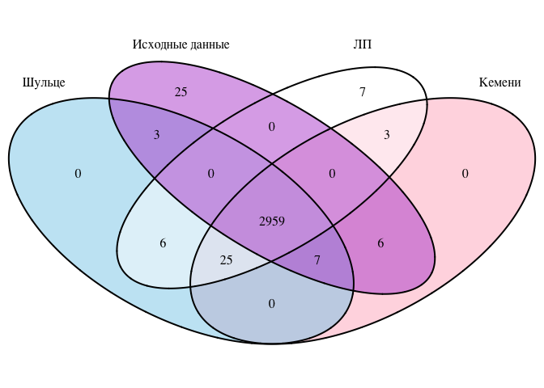

[output not shown]

```r
plot.venn(subset(doe,val>3.5 & experts>12))
```

### Информация о параметрах R